# Arbres de Décision

Alexis Remond

09/03/2022

# Chargement des packages

Nous installons d’abord tous les packages dont l’on aura besoin lors de notre analyse de la base de données.

```r
library(tidyverse)
library(car)
```

```r
library(tibble)
library(forcats)
library(ggplot2)
library(readr)
library(dplyr)
library(FactoMineR)
library(factoextra)
library(ggeffects)
library(effects)
library(mlbench)
```

Nous disposons de mesures climatiques et de concentration d’Ozone dans l’air à Los Angeles entre le 1er janvier et le 31 décembre 1976 (données Ozone du package mlbench)

Nous disposons des variables :

V1 : Les Mois de l’année : 1 = Janvier,…, 12 = Décembre V2 : Les Jours du mois V3 : Les Jours de la semaine : 1 = lundi,.,7 = dimanche V4 : La Concentration d’Ozone moyenne horaire maximale du jour V5 : La Hauteur de pression à 500 millibar (en m) mesurée à la base spatiale de Vendenberg V6 : La Vitesse du vent (en miles par heure) à l’aéroport international de Los Angeles (LAX) V7 : L’Humidité (en %) à LAX V8 : La Température (en degrés Farenheit) mesurée à Sandburg V9 : La Température (en degrés Farenheit) mesurée à El Monte V10 : La Hauteur de la couche d’inversion (en pieds) V11 : Le Gradient de pression de LAX à Daggett (en millimètre de mercure) V12 : La Température de la couche d’inversion (en degrés Farenheit) V13 : La Visibilité mesurée à LAX (en miles)

Nous avons pour objectif : - D’analyser les facteurs de Ozone par l’Ozone à Los Angeles - D’appliquer le modèle d’arbre de décision en regression et en classification - De produire un compte rendu avant le 27 mars.

On importe la base de données “Ozone” du package “mlbench”

```r
library(tidyverse)
data("Ozone", package = "mlbench")
donnees = Ozone

knitr::kable(head(Ozone))
```

| V1 | V2 | V3 | V4 | V5 | V6 | V7 | V8 | V9 | V10 | V11 | V12 | V13 |
| --- | --- | --- | --- | --- | --- | --- | --- | --- | --- | --- | --- | --- |
| 1 | 1 | 4 | 3 | 5480 | 8 | 20 | NA | NA | 5000 | -15 | 30.56 | 200 |
| 1 | 2 | 5 | 3 | 5660 | 6 | NA | 38 | NA | NA | -14 | NA | 300 |
| 1 | 3 | 6 | 3 | 5710 | 4 | 28 | 40 | NA | 2693 | -25 | 47.66 | 250 |
| 1 | 4 | 7 | 5 | 5700 | 3 | 37 | 45 | NA | 590 | -24 | 55.04 | 100 |
| 1 | 5 | 1 | 5 | 5760 | 3 | 51 | 54 | 45.32 | 1450 | 25 | 57.02 | 60 |
| 1 | 6 | 2 | 6 | 5720 | 4 | 69 | 35 | 49.64 | 1568 | 15 | 53.78 | 60 |

# Partie 1

## 1. Mise en forme des données de Ozone

### Renommage des variables

On renomme les variables pour avoir une idée nette et précise de celles-ci

```r
Ozone = Ozone %>% rename("Mois" = V1,
                     "Jour_mois" = V2,
                     "Jour_semaine" = V3,
                     "Concentration_Ozone" = V4,
                     "Hauteur_pression" = V5,
                     "Vitesse_vent" = V6,
                     "Humidité" = V7,
                     "Température_Sandburg" = V8,
                     "Température_El_Monte" = V9,
                     "Hauteur_couche_inversion" = V10,
                     "Gradient_pression" = V11,
                     "Température_couche_inversion" = V12,
                     "Visibilité" = V13)
```

### Mise au bon format

Puis, on met en format caractère les variables Mois et Jour de la semaine

```r
Ozone$Mois<-factor(Ozone$Mois,labels=c("Janvier", "Février", "Mars", "Avril", "Mai", "Juin", "Juillet", "Aout", "Septembre", "Octobre", "Novembre", "Décembre"))

Ozone$Jour_semaine<-factor(Ozone$Jour_semaine,labels=c("Lundi", "Mardi", "Mercredi", "Jeudi", "Vendredi", "Samedi", "Dimanche"))
```

### Recodage éventuel

Ensuite, on va recoder certaines variables afin de pouvoir mieux les utiliser pour nos prochaines analyses On passe les temperatures en Celsius.

```r
Ozone$Température_couche_inversion = (Ozone$Température_couche_inversion-32)/1.8
Ozone$Température_Sandburg = (Ozone$Température_Sandburg-32)/1.8
Ozone$Température_El_Monte = (Ozone$Température_El_Monte-32)/1.8
```

```r
Ozone$Visibilité = Ozone$Visibilité * 0.62137
Ozone$Vitesse_vent = Ozone$Vitesse_vent * 0.62137
```

Pour la variable “Hauteur_couche_inversion”, on recode pour que celle-ci soit en km aussi.

```r
Ozone$Hauteur_couche_inversion = Ozone$Hauteur_couche_inversion * 0.0003048
```

Enfin, on regarde si il y a des valeurs manquantes dans notre base de données

### Gestion des valeurs manquantes

```r
sum(is.na(Ozone))
```

```
## [1] 203
```

```r
summary(is.na(Ozone))
```

```
##     Mois         Jour_mois       Jour_semaine    Concentration_Ozone
##  Mode :logical   Mode :logical   Mode :logical   Mode :logical
##  FALSE:366       FALSE:366       FALSE:366       FALSE:361
##                                                  TRUE :5
##  Hauteur_pression Vitesse_vent     Humidité       Température_Sandburg
##  Mode :logical    Mode :logical   Mode :logical   Mode :logical
##  FALSE:354        FALSE:366       FALSE:351       FALSE:364
##  TRUE :12                         TRUE :15        TRUE :2
##  Température_El_Monte Hauteur_couche_inversion Gradient_pression
##  Mode :logical        Mode :logical            Mode :logical
##  FALSE:227            FALSE:351                FALSE:365
##  TRUE :139            TRUE :15                 TRUE :1
##  Température_couche_inversion Visibilité
##  Mode :logical                Mode :logical
##  FALSE:352                    FALSE:366
##  TRUE :14
```

On voit qu’il y a 203 valeurs manquantes dans notre jeu de données. On voit que la variable Concentration_Ozone a 5 valeurs manquantes, la variable Hauteur_pression a 12 valeurs manquantes, la variable Humidité a 15 valeurs manquantes, la variable Température_Sandburg a 2 valeurs manquantes, la variable Température_El_Monte a 139 valeurs manquantes, la variable Hauteur_couche_inversion a 15 valeurs manquantes, la variable Gradient_pression a 1 valeur manquante, la variable Température_couche_inversion a 14 valeurs manquantes.

## 2. Analyse des données de pollution

On peut regarder à quoi ressemble notre jeu de données, avec le minimum, le premier quartile, la mediane, la moyenne, le troisième quartile et le maximum.

```r
summary(Ozone)
```

```
##       Mois       Jour_mois     Jour_semaine Concentration_Ozone
##  Janvier: 31   1      : 12   Lundi   :52    Min.   : 1.00
##  Mars   : 31   2      : 12   Mardi   :52    1st Qu.: 5.00
##  Mai    : 31   3      : 12   Mercredi:52    Median : 9.00
##  Juillet: 31   4      : 12   Jeudi   :53    Mean   :11.53
##  Aout   : 31   5      : 12   Vendredi:53    3rd Qu.:16.00
##  Octobre: 31   6      : 12   Samedi  :52    Max.   :38.00
##  (Other):180   (Other):294   Dimanche:52    NA's   :5
##  Hauteur_pression  Vitesse_vent      Humidité     Température_Sandburg
##  Min.   :5320     Min.   :0.000   Min.   :19.00   Min.   :-3.889
##  1st Qu.:5700     1st Qu.:1.864   1st Qu.:49.00   1st Qu.:10.556
##  Median :5770     Median :3.107   Median :65.00   Median :16.667
##  Mean   :5753     Mean   :3.025   Mean   :58.48   Mean   :16.619
##  3rd Qu.:5830     3rd Qu.:3.728   3rd Qu.:73.00   3rd Qu.:22.222
##  Max.   :5950     Max.   :6.835   Max.   :93.00   Max.   :33.889
##  NA's   :12                       NA's   :15      NA's   :2
##  Température_El_Monte Hauteur_couche_inversion Gradient_pression
##  Min.   :-2.40        Min.   :0.03383          Min.   :-69.0
##  1st Qu.: 9.85        1st Qu.:0.27127          1st Qu.:-10.0
##  Median :13.90        Median :0.64770          Median : 24.0
##  Mean   :13.80        Mean   :0.78972          Mean   : 17.8
##  3rd Qu.:18.95        3rd Qu.:1.52400          3rd Qu.: 45.0
##  Max.   :28.10        Max.   :1.52400          Max.   :107.0
##  NA's   :139          NA's   :15               NA's   :1
##  Température_couche_inversion   Visibilité
##  Min.   :-2.50                Min.   :  0.00
##  1st Qu.:10.70                1st Qu.: 43.50
##  Median :16.80                Median : 68.35
##  Mean   :16.07                Mean   : 76.62
##  3rd Qu.:21.40                3rd Qu.: 93.21
##  Max.   :33.20                Max.   :310.69
##  NA's   :14
```

```r
str(Ozone)
```

```
## 'data.frame':    366 obs. of  13 variables:
##  $ Mois                        : Factor w/ 12 levels "Janvier","Février",..: 1 1 1 1 1 1 1 1 1 1 ...
##  $ Jour_mois                   : Factor w/ 31 levels "1","2","3","4",..: 1 2 3 4 5 6 7 8 9 10 ...
##  $ Jour_semaine                : Factor w/ 7 levels "Lundi","Mardi",..: 4 5 6 7 1 2 3 4 5 6 ...
##  $ Concentration_Ozone         : num  3 3 3 5 5 6 4 4 6 7 ...
##  $ Hauteur_pression            : num  5480 5660 5710 5700 5760 5720 5790 5790 5700 5700 ...
##  $ Vitesse_vent                : num  4.97 3.73 2.49 1.86 1.86 ...
##  $ Humidité                    : num  20 NA 28 37 51 69 19 25 73 59 ...
##  $ Température_Sandburg        : num  NA 3.33 4.44 7.22 12.22 ...
##  $ Température_El_Monte        : num  NA NA NA NA 7.4 9.8 8 11.5 8.9 NA ...
##  $ Hauteur_couche_inversion    : num  1.524 NA 0.821 0.18 0.442 ...
##  $ Gradient_pression           : num  -15 -14 -25 -24 25 15 -33 -28 23 -2 ...
##  $ Température_couche_inversion: num  -0.8 NA 8.7 12.8 13.9 12.1 12.3 18.2 11.4 9.1 ...
##  $ Visibilité                  : num  124.3 186.4 155.3 62.1 37.3 ...
```

On regroupe les variables quantitatives dans une seule variable, et les variables qualitatives dans une seule variable. Ceci va nous aider pour nos analyses.

```r
Ozone_quanti = Ozone %>% select( Concentration_Ozone,Hauteur_pression, Vitesse_vent, Humidité,Température_Sandburg, Température_El_Monte, Hauteur_couche_inversion,Gradient_pression, Température_couche_inversion, Visibilité)
Ozone_quali = Ozone %>% select(Mois, Jour_semaine)
```

### Statistiques univariées

#### Variables qualitatives

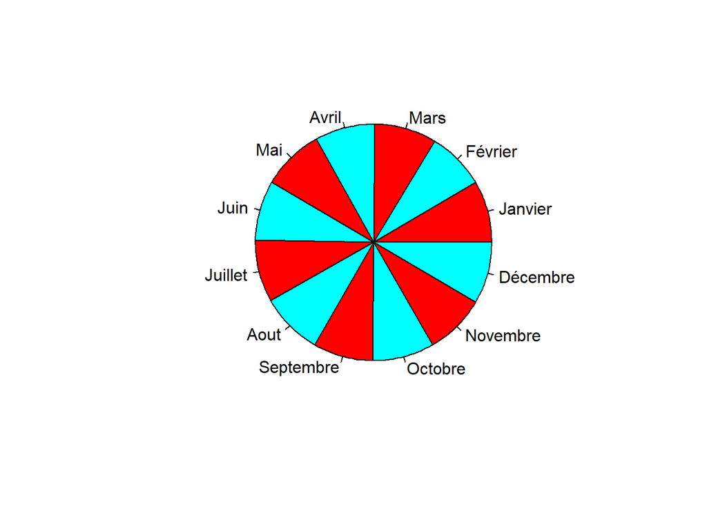

```r
p1 = prop.table(table(Ozone$Mois))
pie(p1, col = c("red","cyan"))
```

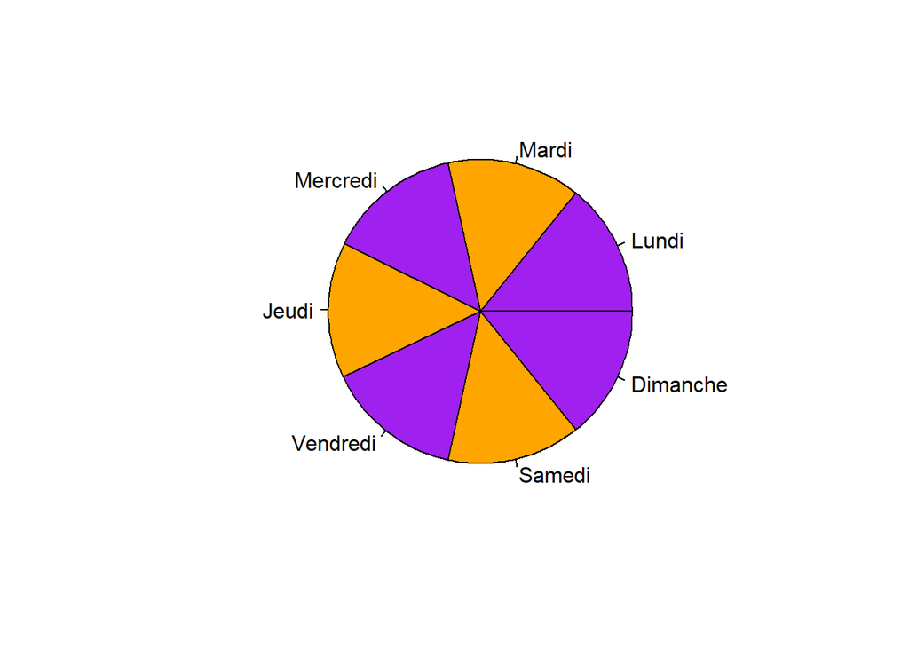

```r
p2 = prop.table(table(Ozone$Jour_semaine))
pie(p2, col = c("purple","orange"))
```

Faire une statistique univariée sur des variables qualitatives ne sert à rien sur notre base de données car nous avons le meme nombre de donnée distincts.

#### Variables quantitatives

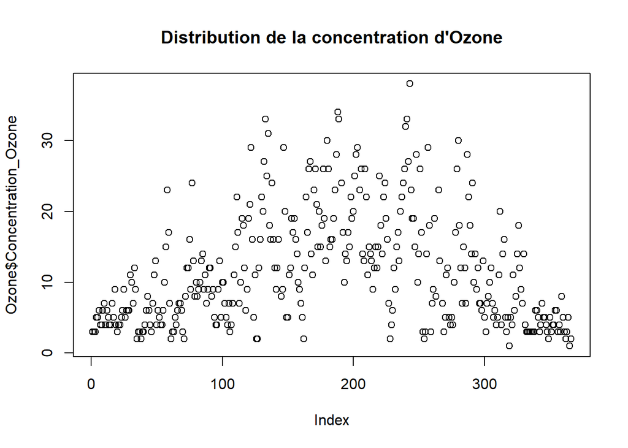

```r
plot(Ozone$Concentration_Ozone, main = "Distribution de la concentration d'Ozone")
```

On crée une variable avec toutes les variables numériques de notre jeu de données, afin que ce soit plus facile pour nous de les analyser.

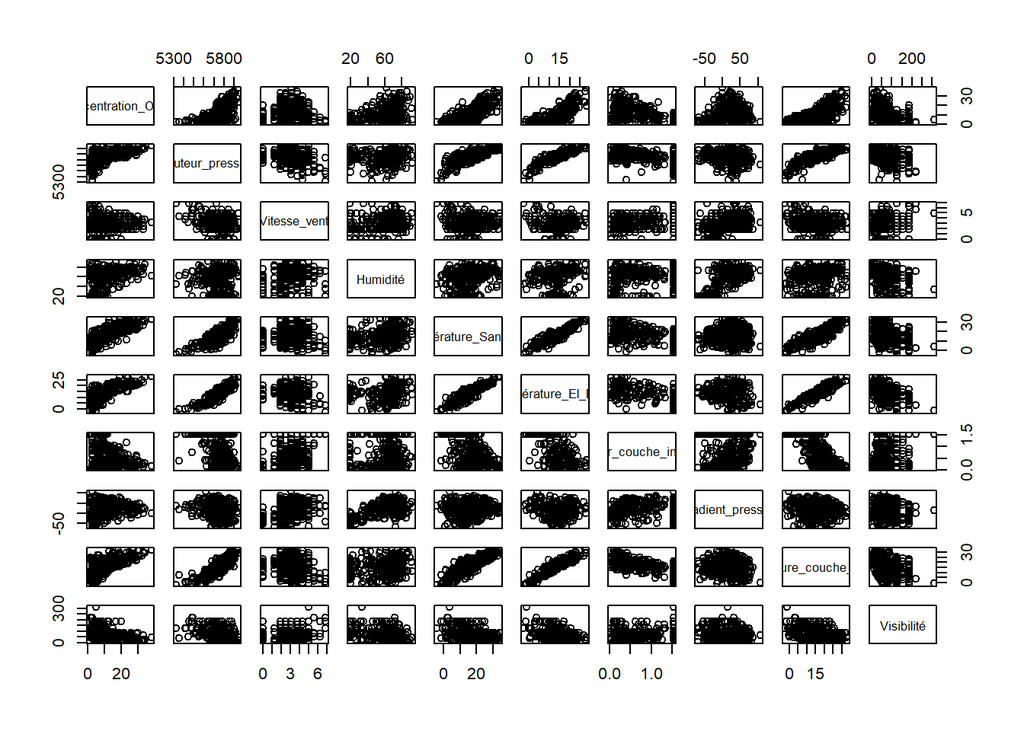

```r
library(dplyr)
var_num = Ozone %>% select(Concentration_Ozone,Hauteur_pression, Vitesse_vent, Humidité,Température_Sandburg, Température_El_Monte, Hauteur_couche_inversion, Gradient_pression, Température_couche_inversion, Visibilité)
pairs(var_num)
```

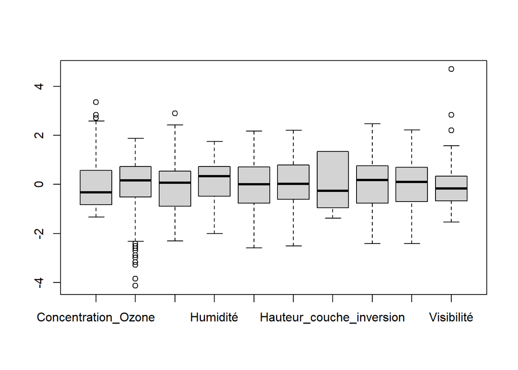

```r
boxplot_num=scale(var_num)
boxplot(boxplot_num)
```

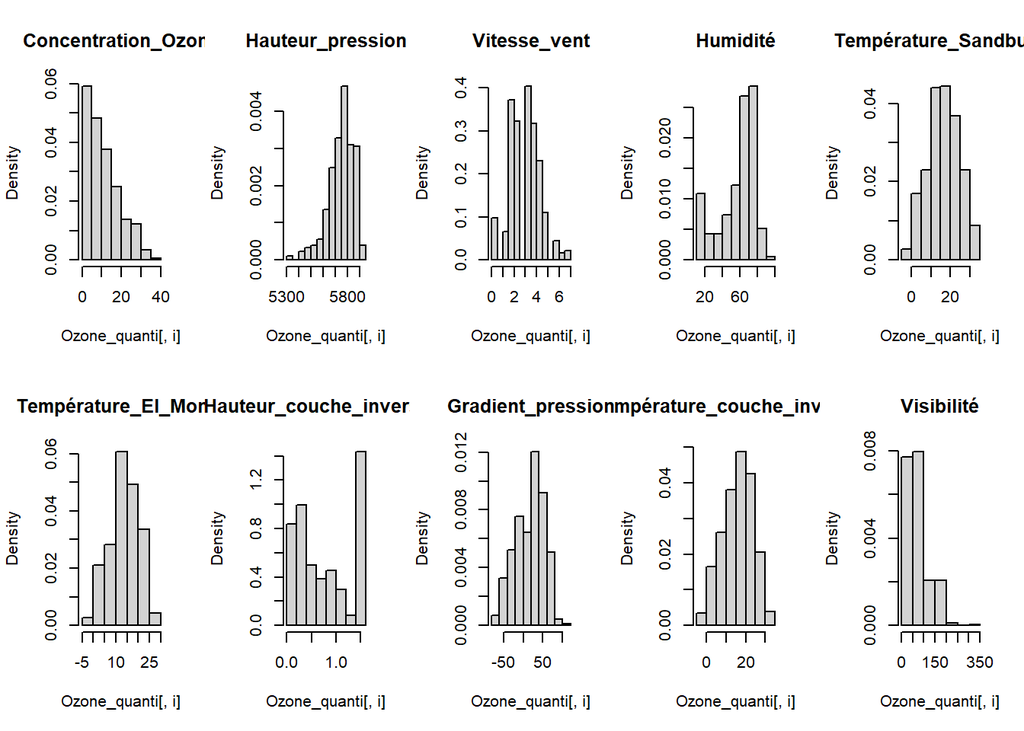

```r
sequence=c(1:10)
par(mfrow = c(2,5))
for(i in sequence){
  hist(Ozone_quanti[ , i],
       prob = TRUE,
       main = colnames(Ozone_quanti)[i])
}
```

### Statistiques bivariées

#### Variables qualitatives

```r
table(Ozone_quali$Mois,Ozone_quali$Jour_semaine)
```

```
##
##             Lundi Mardi Mercredi Jeudi Vendredi Samedi Dimanche
##   Janvier       4     4        4     5        5      5        4
##   Février       4     4        4     4        4      4        5
##   Mars          5     5        5     4        4      4        4
##   Avril         4     4        4     5        5      4        4
##   Mai           5     4        4     4        4      5        5
##   Juin          4     5        5     4        4      4        4
##   Juillet       4     4        4     5        5      5        4
##   Aout          5     5        4     4        4      4        5
##   Septembre     4     4        5     5        4      4        4
##   Octobre       4     4        4     4        5      5        5
##   Novembre      5     5        4     4        4      4        4
##   Décembre      4     4        5     5        5      4        4
```

```r
chisq.test(Ozone$Mois, Ozone$Jour_semaine)
```

```
##
##  Pearson's Chi-squared test
##
## data:  Ozone$Mois and Ozone$Jour_semaine
## X-squared = 4.2221, df = 66, p-value = 1
```

#### Variables quantitatives

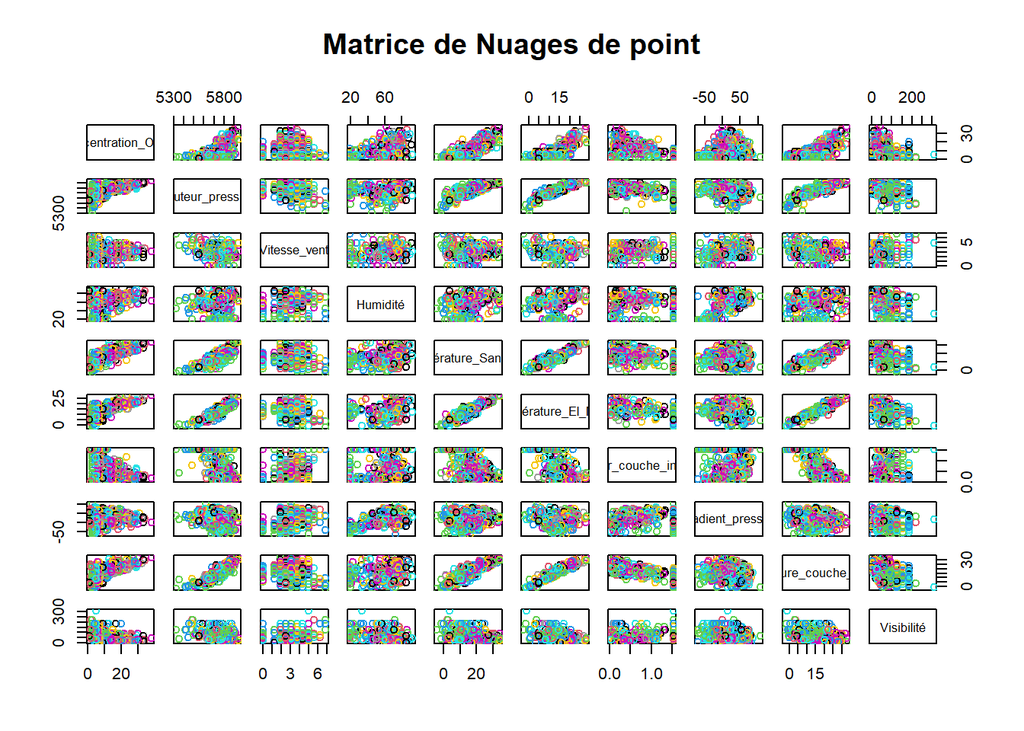

```r
par(mfrow = c(1, 1))
pairs(var_num, col = Ozone$Concentration_Ozone,main="Matrice de Nuages de point")
```

### Corrélation

On fait une matrice de corrélation, afin de voir la dépendance entre plusieurs variables.

```r
var_num=var_num%>%drop_na()
mcor = cor(var_num)
mcor
```

```
##                              Concentration_Ozone Hauteur_pression Vitesse_vent
## Concentration_Ozone                    1.0000000       0.59442132   0.08415020
## Hauteur_pression                       0.5944213       1.00000000  -0.23161673
## Vitesse_vent                           0.0841502      -0.23161673   1.00000000
## Humidité                               0.4810812       0.03869121   0.30356343
## Température_Sandburg                   0.7724696       0.80633038   0.04122208
## Température_El_Monte                   0.7590223       0.89689385  -0.06983510
## Hauteur_couche_inversion              -0.5539252      -0.50891157   0.12834881
## Gradient_pression                      0.1731514      -0.24549047   0.37328762
## Température_couche_inversion           0.7175658       0.85642134  -0.12959891
## Visibilité                            -0.4760401      -0.34272720   0.04534341
##                                 Humidité Température_Sandburg
## Concentration_Ozone           0.48108120           0.77246956
## Hauteur_pression              0.03869121           0.80633038
## Vitesse_vent                  0.30356343           0.04122208
## Humidité                      1.00000000           0.33132296
## Température_Sandburg          0.33132296           1.00000000
## Température_El_Monte          0.21158607           0.91396229
## Hauteur_couche_inversion     -0.24703914          -0.51539621
## Gradient_pression             0.62433536           0.11765666
## Température_couche_inversion  0.19101936           0.84310310
## Visibilité                   -0.45750232          -0.41038641
##                              Température_El_Monte Hauteur_couche_inversion
## Concentration_Ozone                     0.7590223               -0.5539252
## Hauteur_pression                        0.8968939               -0.5089116
## Vitesse_vent                           -0.0698351                0.1283488
## Humidité                                0.2115861               -0.2470391
## Température_Sandburg                    0.9139623               -0.5153962
## Température_El_Monte                    1.0000000               -0.5796583
## Hauteur_couche_inversion               -0.5796583                1.0000000
## Gradient_pression                      -0.1209160                0.1135024
## Température_couche_inversion            0.9308099               -0.7828614
## Visibilité                             -0.4389790                0.3966979
##                              Gradient_pression Température_couche_inversion
## Concentration_Ozone                  0.1731514                    0.7175658
## Hauteur_pression                    -0.2454905                    0.8564213
## Vitesse_vent                         0.3732876                   -0.1295989
## Humidité                             0.6243354                    0.1910194
## Température_Sandburg                 0.1176567                    0.8431031
## Température_El_Monte                -0.1209160                    0.9308099
## Hauteur_couche_inversion             0.1135024                   -0.7828614
## Gradient_pression                    1.0000000                   -0.2066387
## Température_couche_inversion        -0.2066387                    1.0000000
## Visibilité                          -0.1200549                   -0.4377177
##                               Visibilité
## Concentration_Ozone          -0.47604005
## Hauteur_pression             -0.34272720
## Vitesse_vent                  0.04534341
## Humidité                     -0.45750232
## Température_Sandburg         -0.41038641
## Température_El_Monte         -0.43897902
## Hauteur_couche_inversion      0.39669789
## Gradient_pression            -0.12005488
## Température_couche_inversion -0.43771768
## Visibilité                    1.00000000
```

On peut voir sur la table les coefficients de corrrélation sont montrés entre les différentes paires possibles de variables.

- Table de corrélation

```r
df=as.data.frame(as.table(cor(var_num)))
dff=df[1:10,]
```

On crée un tableau afin de voir mieux en détails nos résultat.

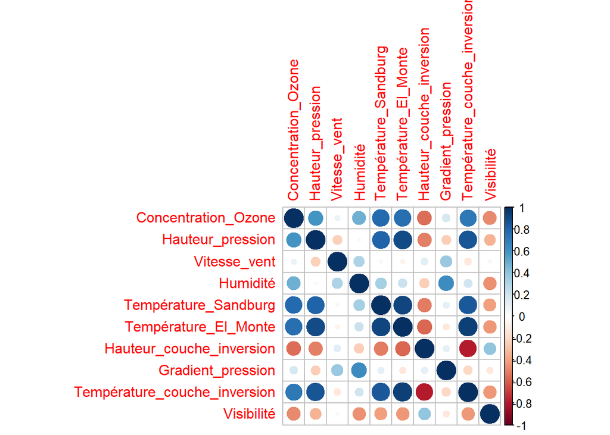

```r
library(corrplot)
corrplot(mcor, method="circle")
```

### Variables qualitatives et quantitatives

La variable “Mois”, en fonction des variables quantitatives.

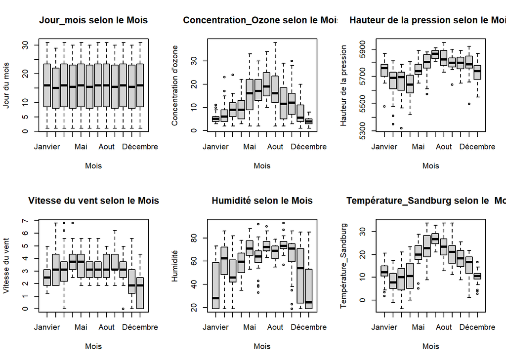

```r
par(mfrow = c(2,3))
boxplot(Jour_mois ~ Mois, data = Ozone, main = "Jour_mois selon le Mois",ylab="Jour du mois",xlab="Mois")
boxplot(Concentration_Ozone ~ Mois, data = Ozone, main = "Concentration_Ozone selon le Mois",ylab="Concentration d'ozone",xlab="Mois")
boxplot(Hauteur_pression ~ Mois, data = Ozone, main = "Hauteur de la pression selon le Mois",ylab="Hauteur de la pression",xlab="Mois")
boxplot(Vitesse_vent ~ Mois, data = Ozone, main = "Vitesse du vent selon le Mois",ylab="Vitesse du vent",xlab="Mois")
boxplot(Humidité ~ Mois, data = Ozone, main = "Humidité selon le Mois",ylab="Humidité",xlab="Mois")
boxplot(Température_Sandburg ~ Mois, data = Ozone, main = "Température_Sandburg selon le  Mois",ylab="Température_Sandburg",xlab="Mois")
```

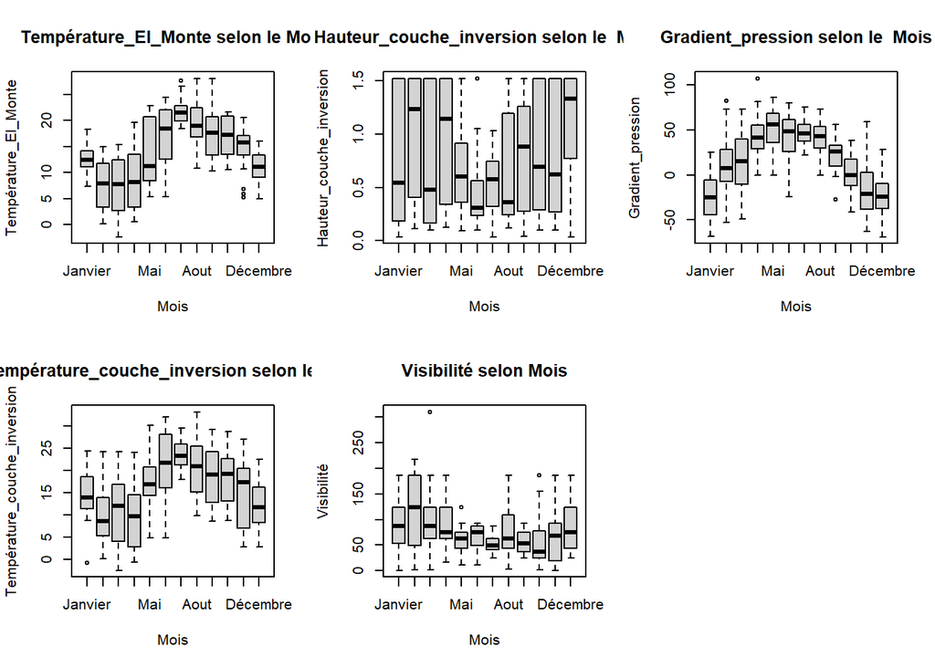

```r
boxplot(Température_El_Monte ~ Mois, data = Ozone, main = "Température_El_Monte selon le Mois",ylab="Température_El_Monte",xlab="Mois")
boxplot(Hauteur_couche_inversion ~ Mois, data = Ozone, main = "Hauteur_couche_inversion selon le  Mois",ylab="Hauteur_couche_inversion",xlab="Mois")
boxplot(Gradient_pression ~ Mois, data = Ozone, main = "Gradient_pression selon le  Mois",ylab="Gradient_pression",xlab="Mois")
boxplot(Température_couche_inversion ~ Mois, data = Ozone, main = "Température_couche_inversion selon le Mois",ylab="Température_couche_inversion",xlab="Mois")
boxplot(Visibilité ~ Mois, data = Ozone, main = "Visibilité selon Mois",ylab="Visibilité",xlab="Mois")
```

La variable “Jour_semaine”, en fonction des variables quantitatives.

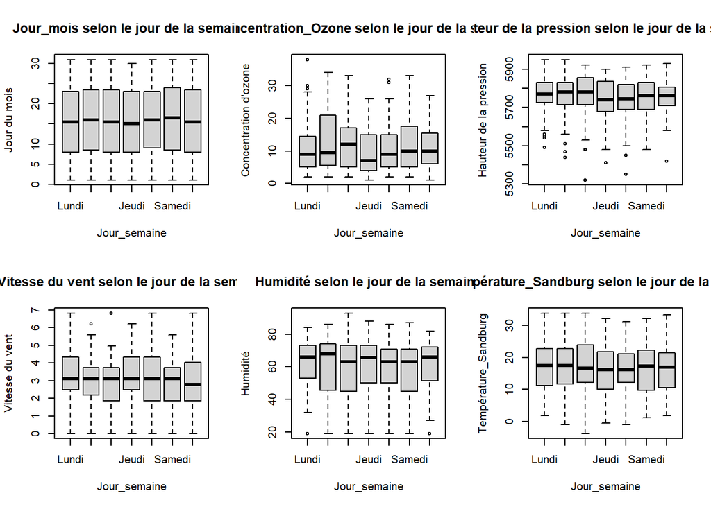

```r
par(mfrow = c(2,3))
boxplot(Jour_mois ~ Jour_semaine, data = Ozone, main = "Jour_mois selon le jour de la semaine",ylab="Jour du mois",xlab="Jour_semaine")
boxplot(Concentration_Ozone ~ Jour_semaine, data = Ozone, main = "Concentration_Ozone selon le jour de la semaine",ylab="Concentration d'ozone",xlab="Jour_semaine")
boxplot(Hauteur_pression ~ Jour_semaine, data = Ozone, main = "Hauteur de la pression selon le jour de la semaine",ylab="Hauteur de la pression",xlab="Jour_semaine")
boxplot(Vitesse_vent ~ Jour_semaine, data = Ozone, main = "Vitesse du vent selon le jour de la semaine",ylab="Vitesse du vent",xlab="Jour_semaine")
boxplot(Humidité ~ Jour_semaine, data = Ozone, main = "Humidité selon le jour de la semaine",ylab="Humidité",xlab="Jour_semaine")
boxplot(Température_Sandburg ~ Jour_semaine, data = Ozone, main = "Température_Sandburg selon le jour de la semaine",ylab="Température_Sandburg",xlab="Jour_semaine")
```

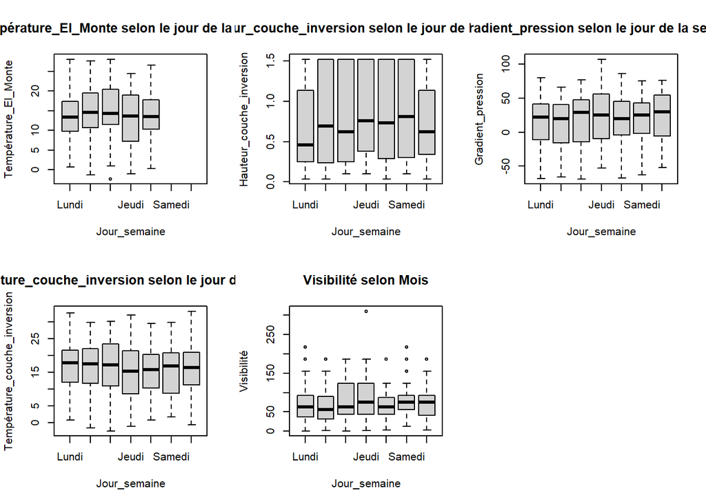

```r
boxplot(Température_El_Monte ~ Jour_semaine, data = Ozone, main = "Température_El_Monte selon le jour de la semaine",ylab="Température_El_Monte",xlab="Jour_semaine")
boxplot(Hauteur_couche_inversion ~ Jour_semaine, data = Ozone, main = "Hauteur_couche_inversion selon le jour de la semaine",ylab="Hauteur_couche_inversion",xlab="Jour_semaine")
boxplot(Gradient_pression ~ Jour_semaine, data = Ozone, main = "Gradient_pression selon le jour de la semaine",ylab="Gradient_pression",xlab="Jour_semaine")
boxplot(Température_couche_inversion ~ Jour_semaine, data = Ozone, main = "Température_couche_inversion selon le jour de la semaine",ylab="Température_couche_inversion",xlab="Jour_semaine")
boxplot(Visibilité ~ Jour_semaine, data = Ozone, main = "Visibilité selon Mois",ylab="Visibilité",xlab="Jour_semaine")
```

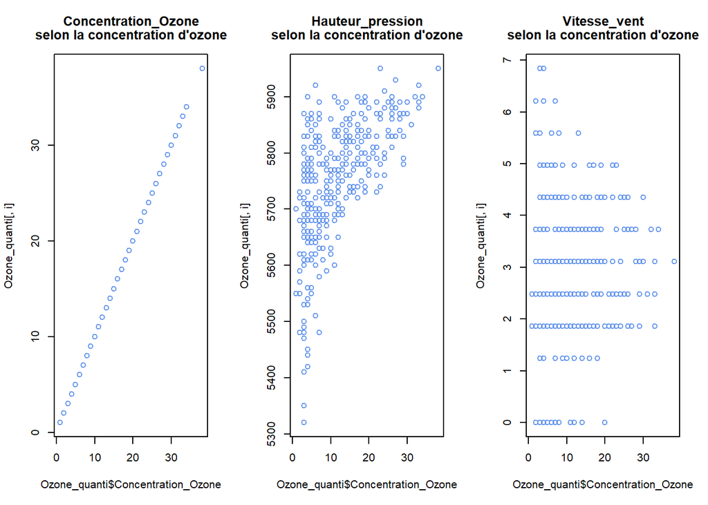

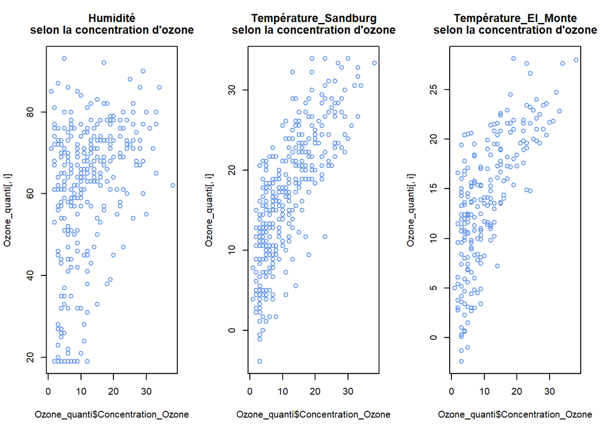

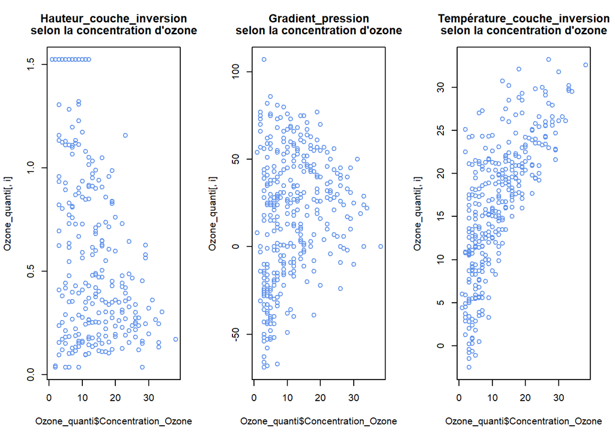

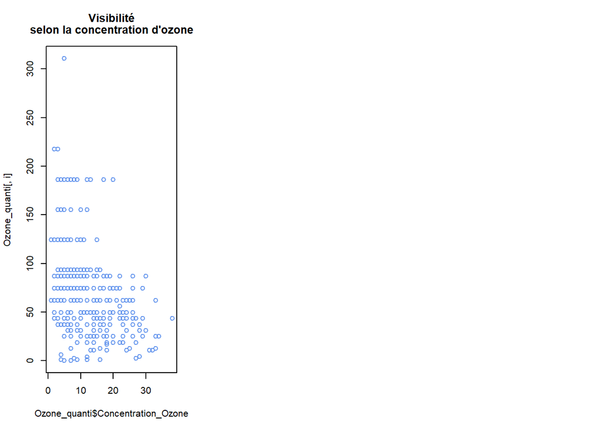

```r
sequence=1:10
par(mfrow = c(1,3))
for(i in sequence){
  plot(Ozone_quanti[ , i]~Ozone_quanti$Concentration_Ozone,
       main = c(colnames(Ozone_quanti)[i],"selon la concentration d'ozone"),col="cornflowerblue")
}
```

### Analyses en composantes principales

l’Analyses en composantes principales (ACP) permet de voir s’il y a des corrélations fortes entre les variables explicatives, ce qui à terme permet de pré-sélectionner les variables (2 variables colinéaires auront le même effet dans un modèle de type linéaire ou logistique)

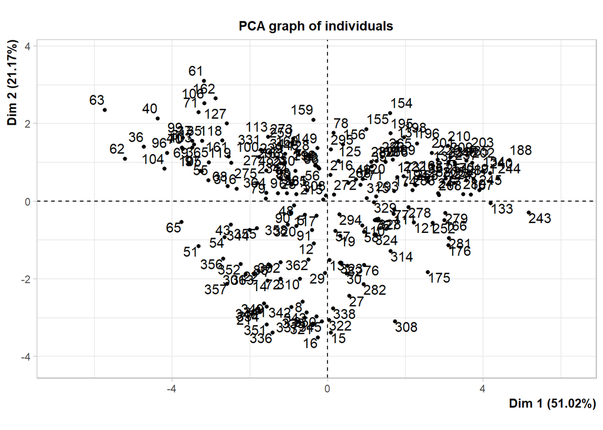

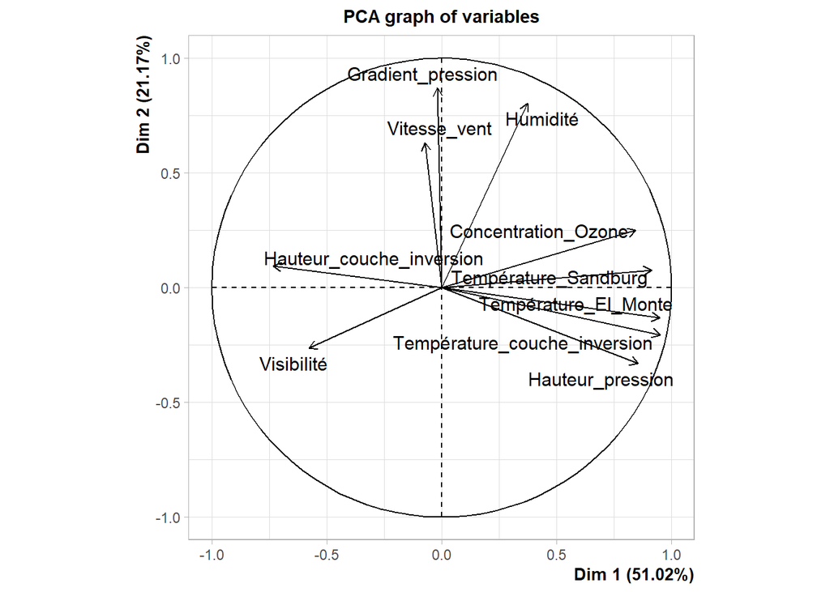

```r
library(FactoMineR)
Ozone.acp=PCA(var_num,ncp=13, graph=TRUE)
```

#### Choix du nombre de facteurs

Nous avons appris en cours que la règle de Kaiser et l’éboulie des valeurs propres peuvent nous aider à choisir le nombre de facteurs. La règle de Kaiser permet de garder les axes qui correspondent aux valeurs propres supérieures à 1. L’ébouli des valeurs propres sert à garder les axes qui correspondent aux valeurs propres situées avant le point d’inflexion.

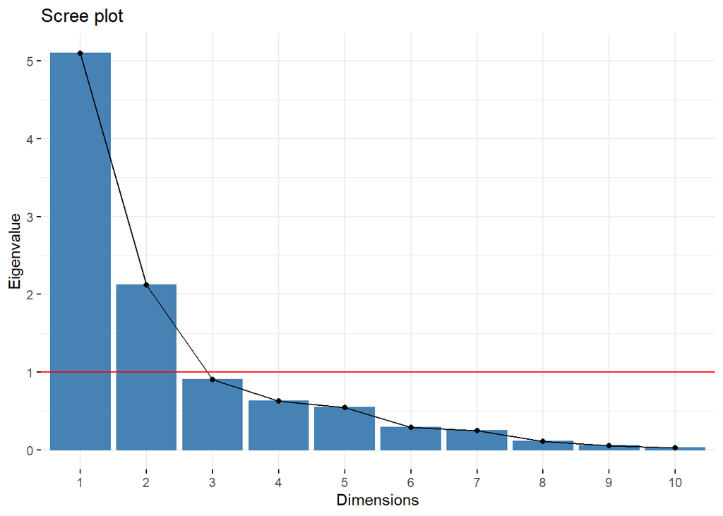

```r
library(factoextra)
vp=Ozone.acp$eig %>% data.frame %>% rownames_to_column(var="Composante") %>% as_tibble

fviz_eig(Ozone.acp,choice="eigenvalue") +
  geom_hline(yintercept = 1,col="red")
```

##### Pourcentage de variance expliquée cumulée

On utilise le pourcentage de variance expliqué cumulée, autrement appelé règle empirique, pour garder les facteurs qui sont supérieurs à un certain pourcentage. Ici, on prendra 90%. Pour cette méthode, on gardera les facteurs ayant un pourcentage de variance cumulée inférieure ou égale à notre seuil de 90%, jusqu’à avoir dépassé ce seuil.

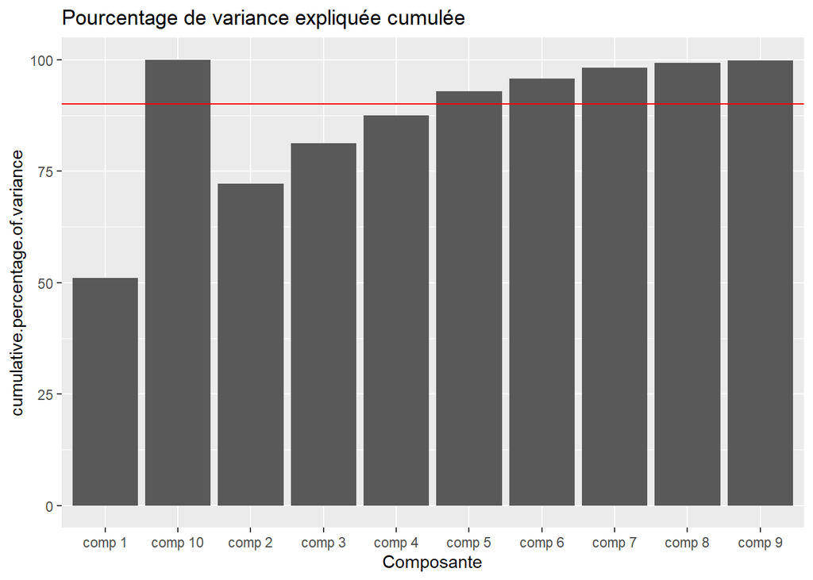

```r
ggplot(vp) + geom_col(aes(x=Composante, y = cumulative.percentage.of.variance)) +
  ggtitle("Pourcentage de variance expliquée cumulée") + geom_hline(aes(yintercept=90),color='red')
```

##### Pourcentage de variance expliquée

Ici, on utilise un seuil de 10%

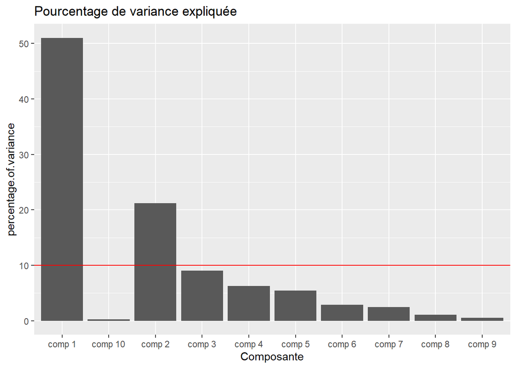

```r
ggplot(vp) + geom_col(aes(x=Composante, y = percentage.of.variance)) +
  ggtitle("Pourcentage de variance expliquée") + geom_hline(aes(yintercept=10),color='red')
```

On peux voir sur ce graphiques que les composantes 1 et 2 ont un pourcentage de variance expliqué supérieur à 10%